# Churn Prediction

This project predicts Churn from an organisation's data. Churn rate is a measure of the number of customers or employees who leave a company during a given period. It can also refer to the amount of revenue lost as a result of the departures. Changes in a business's churn rate can provide valuable insight into an organization.

This project will attempt to compare predictions from six models to find the best for the task.

```python
# Importin relevant libraries
import pandas as pd
import numpy as np
import matplotlib.pyplot as plt
import seaborn as sns
from sklearn.model_selection import train_test_split, GridSearchCV, RandomizedSearchCV
from sklearn.svm import SVC
from sklearn.metrics import accuracy_score, confusion_matrix, classification_report, roc_auc_score, recall_score, precision_score, f1_score, make_scorer, fbeta_score
from sklearn.preprocessing import StandardScaler, LabelEncoder, OneHotEncoder
from sklearn.linear_model import LogisticRegression, Lasso, LassoCV
from sklearn.ensemble import RandomForestClassifier, GradientBoostingClassifier
from sklearn.tree import DecisionTreeClassifier
from sklearn.neighbors import KNeighborsClassifier
from imblearn.over_sampling import SMOTE
from sklearn.pipeline import Pipeline
import warnings
warnings.filterwarnings('ignore')

# Set visualization style
sns.set_style("whitegrid")
plt.rcParams['figure.figsize'] = (10, 6)

print("Libraries loaded successfully!")
```

```
Libraries loaded successfully!
```

## Loading and Initial Exploration of the Dataset

```python
# Initialise file path
filepath = 'Churn_Modelling.csv'  # Update this path as necessary

# Load dataset
try:
    df = pd.read_csv(filepath)
    print("Dataset loaded successfully!")
except FileNotFoundError:
    print("Dataset file not found. Please check file path and/or file extension.")
```

```
Dataset loaded successfully!
```

```python
# Preview the dataset
df.head()
```

[output not shown]

```python
# Check Data Shape
df.shape
```

```
(10000, 14)
```

```python
# Get Data Info
df.info()
```

```
<class 'pandas.core.frame.DataFrame'>
RangeIndex: 10000 entries, 0 to 9999
Data columns (total 14 columns):
 #   Column           Non-Null Count  Dtype
---  ------           --------------  -----
 0   RowNumber        10000 non-null  int64
 1   CustomerId       10000 non-null  int64
 2   Surname          10000 non-null  object
 3   CreditScore      10000 non-null  int64
 4   Geography        10000 non-null  object
 5   Gender           10000 non-null  object
 6   Age              10000 non-null  int64
 7   Tenure           10000 non-null  int64
 8   Balance          10000 non-null  float64
 9   NumOfProducts    10000 non-null  int64
 10  HasCrCard        10000 non-null  int64
 11  IsActiveMember   10000 non-null  int64
 12  EstimatedSalary  10000 non-null  float64
 13  Churn            10000 non-null  int64
dtypes: float64(2), int64(9), object(3)
memory usage: 1.1+ MB
```

```python
# Statistical Summary of numeric columns
df.describe()
```

|  | RowNumber | CustomerId | CreditScore | Age | Tenure | Balance | NumOfProducts | HasCrCard | IsActiveMember | EstimatedSalary | Churn |
| --- | --- | --- | --- | --- | --- | --- | --- | --- | --- | --- | --- |
| count | 10000.00000 | 1.000000e+04 | 10000.000000 | 10000.000000 | 10000.000000 | 10000.000000 | 10000.000000 | 10000.00000 | 10000.000000 | 10000.000000 | 10000.000000 |
| mean | 5000.50000 | 1.569094e+07 | 650.528800 | 38.921800 | 5.012800 | 76485.889288 | 1.530200 | 0.70550 | 0.515100 | 100090.239881 | 0.203700 |
| std | 2886.89568 | 7.193619e+04 | 96.653299 | 10.487806 | 2.892174 | 62397.405202 | 0.581654 | 0.45584 | 0.499797 | 57510.492818 | 0.402769 |
| min | 1.00000 | 1.556570e+07 | 350.000000 | 18.000000 | 0.000000 | 0.000000 | 1.000000 | 0.00000 | 0.000000 | 11.580000 | 0.000000 |
| 25% | 2500.75000 | 1.562853e+07 | 584.000000 | 32.000000 | 3.000000 | 0.000000 | 1.000000 | 0.00000 | 0.000000 | 51002.110000 | 0.000000 |
| 50% | 5000.50000 | 1.569074e+07 | 652.000000 | 37.000000 | 5.000000 | 97198.540000 | 1.000000 | 1.00000 | 1.000000 | 100193.915000 | 0.000000 |
| 75% | 7500.25000 | 1.575323e+07 | 718.000000 | 44.000000 | 7.000000 | 127644.240000 | 2.000000 | 1.00000 | 1.000000 | 149388.247500 | 0.000000 |
| max | 10000.00000 | 1.581569e+07 | 850.000000 | 92.000000 | 10.000000 | 250898.090000 | 4.000000 | 1.00000 | 1.000000 | 199992.480000 | 1.000000 |

```python
# Check for missing values
df.isnull().sum()
```

```
RowNumber          0
CustomerId         0
Surname            0
CreditScore        0
Geography          0
Gender             0
Age                0
Tenure             0
Balance            0
NumOfProducts      0
HasCrCard          0
IsActiveMember     0
EstimatedSalary    0
Churn              0
dtype: int64
```

`NOTE`

No missing values identified in both features and target

```python
# Check for Duplicates
df.duplicated().sum()
```

```
np.int64(0)
```

```python
# Drop unnecessary columns
df = df.drop(['RowNumber', 'CustomerId', 'Surname'], axis=1)
```

```python
# Check columns after dropping
df.columns
```

```
Index(['CreditScore', 'Geography', 'Gender', 'Age', 'Tenure', 'Balance',
       'NumOfProducts', 'HasCrCard', 'IsActiveMember', 'EstimatedSalary',
       'Churn'],
      dtype='object')
```

```python
# numerical features
num_cols = df.select_dtypes(include=['number']).columns
if 'Churn' in num_cols:
    num_cols = num_cols.drop('Churn')
print("Numerical Features:", num_cols)
```

```
Numerical Features: Index(['CreditScore', 'Age', 'Tenure', 'Balance', 'NumOfProducts', 'HasCrCard',
       'IsActiveMember', 'EstimatedSalary'],
      dtype='object')
```

```python
# Categorical features
cat_cols = df.select_dtypes(include=['object']).columns
print("Categorical Features:", cat_cols)
```

```
Categorical Features: Index(['Geography', 'Gender'], dtype='object')
```

## Exploratory Data Analysis (EDA)

```python
# Check target variable distribution
print("\n" + "="*80)
print("TARGET VARIABLE DISTRIBUTION")
print("="*80)
target_counts = df['Churn'].value_counts()
target_percent = 100 * df['Churn'].value_counts(normalize=True)

print("\nStroke Occurrence:")
print(f"  No Churn (0): {target_counts[0]:,} ({target_percent[0]:.2f}%)")
print(f"  Churn (1):    {target_counts[1]:,} ({target_percent[1]:.2f}%)")
print(f"\n  Imbalance Ratio: {target_counts[0]/target_counts[1]:.1f}:1")
```

```
================================================================================
TARGET VARIABLE DISTRIBUTION
================================================================================

Stroke Occurrence:
  No Churn (0): 7,963 (79.63%)
  Churn (1):    2,037 (20.37%)

  Imbalance Ratio: 3.9:1
```

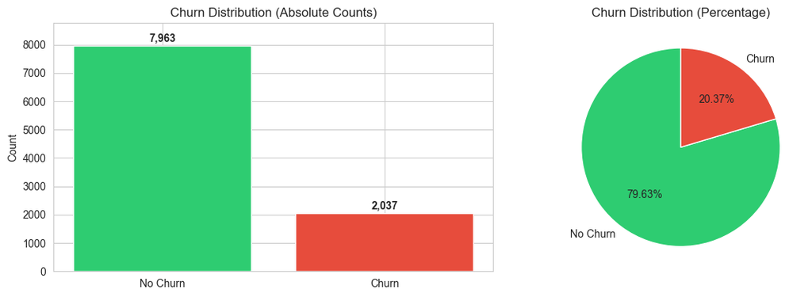

```python
# Visualize target distribution
fig, ax = plt.subplots(1, 2, figsize=(12, 4))

ax[0].bar(['No Churn', 'Churn'], target_counts.values, color=['#2ecc71', '#e74c3c'])
ax[0].set_ylabel('Count')
ax[0].set_title('Churn Distribution (Absolute Counts)')
ax[0].set_ylim(0, max(target_counts.values) * 1.1)
for i, v in enumerate(target_counts.values):
    ax[0].text(i, v + max(target_counts.values)*0.02, f'{v:,}', ha='center', fontweight='bold')

ax[1].pie(target_counts.values, labels=['No Churn', 'Churn'],
          autopct='%1.2f%%', colors=['#2ecc71', '#e74c3c'], startangle=90)
ax[1].set_title('Churn Distribution (Percentage)')

plt.tight_layout()
plt.show()
```

`NOTE`

This shows a highly imbalanced target and would require proper handling

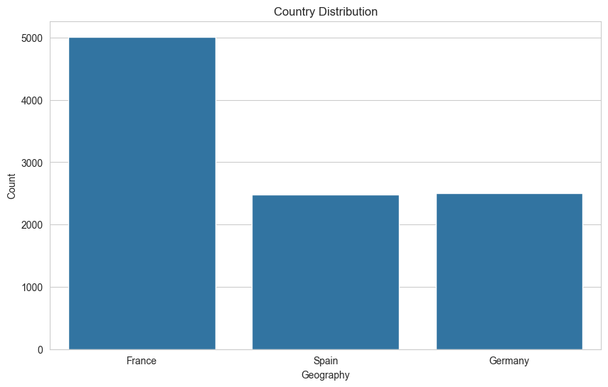

```python
# Plot bar chart for geography column
sns.countplot(data=df, x='Geography')
plt.title('Country Distribution')
plt.ylabel('Count')
plt.show()
```

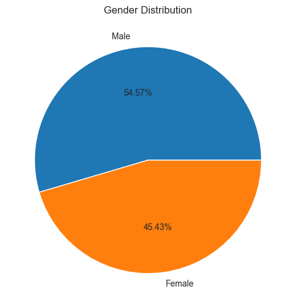

```python
# Visualise Gender distribution
gender_counts = df['Gender'].value_counts()
plt.figure(figsize=(8, 6))
plt.pie(gender_counts.values, labels=gender_counts.index, autopct='%1.2f%%')
plt.title('Gender Distribution')
plt.show()
```

## Data Pre-processing

### Check and Handle Outliers

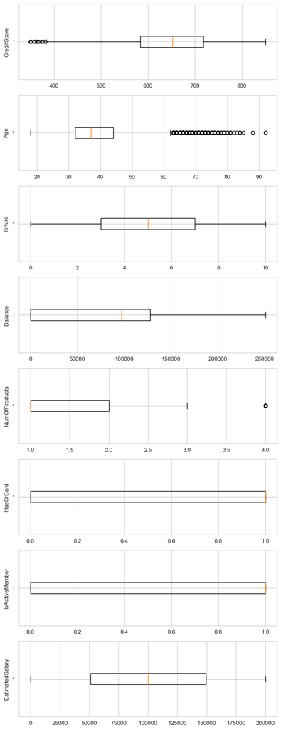

```python
# Check for outliers in numerical features using box plots
fig, axs = plt.subplots(len(num_cols), 1, figsize=(7, 18), dpi=95)
for i, col in enumerate(num_cols):
    axs[i].boxplot(df[col], vert=False)
    axs[i].set_ylabel(col)
plt.tight_layout()
plt.show()
```

```python
# Remove outliers in 'CreditScore' column using IQR method
q1, q3 = np.percentile(df['CreditScore'], [25, 75])
iqr = q3 - q1
lower = q1 - 1.5 * iqr
upper = q3 + 1.5 * iqr
clean_df = df[(df['CreditScore'] >= lower) & (df['CreditScore'] <= upper)]
```

```python
# Remove outliers in 'Age' column using IQR method
q1, q3 = np.percentile(df['Age'], [25, 75])
iqr = q3 - q1
lower = q1 - 1.5 * iqr
upper = q3 + 1.5 * iqr
clean_df = df[(df['Age'] >= lower) & (df['Age'] <= upper)]
```

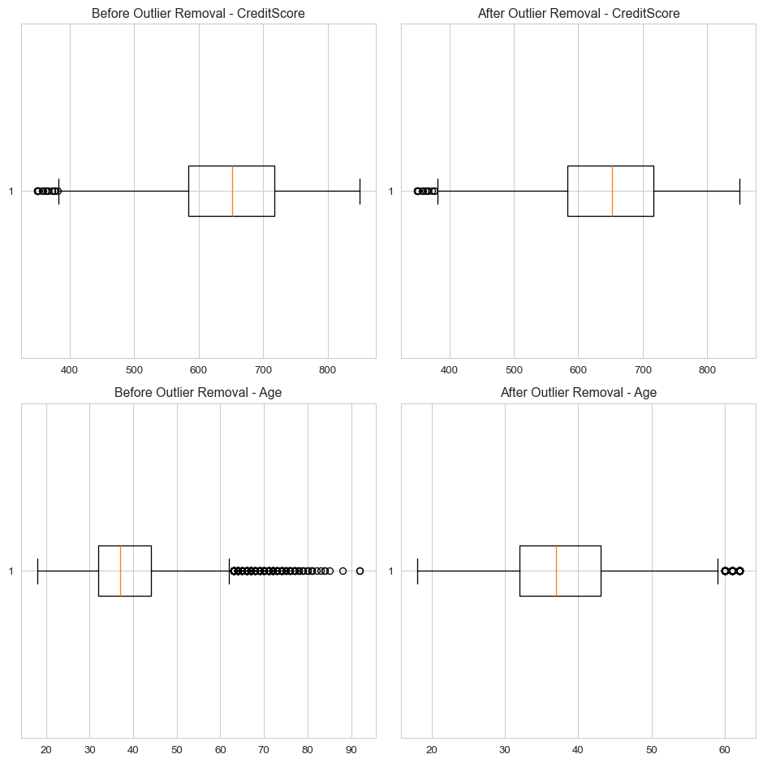

```python
# Compare boxplots before and after outlier removal
fig, axs = plt.subplots(2, 2, figsize=(10, 10), dpi=95)
axs[0,0].boxplot(df['CreditScore'], vert=False)
axs[0,0].set_title('Before Outlier Removal - CreditScore')
axs[0,1].boxplot(clean_df['CreditScore'], vert=False)
axs[0,1].set_title('After Outlier Removal - CreditScore')
axs[1,0].boxplot(df['Age'], vert=False)
axs[1,0].set_title('Before Outlier Removal - Age')
axs[1,1].boxplot(clean_df['Age'], vert=False)
axs[1,1].set_title('After Outlier Removal - Age')
plt.tight_layout()
plt.show()
```

```python
# Shape of the cleaned dataset:
clean_df.shape
```

```
(9641, 11)
```

### Encode Categorical Columns

```python
# Create a copy of the cleaned dataframe for encoding
df_encoded = clean_df.copy()
```

```python
# Encode categorical variables
df_encoded = pd.get_dummies(df_encoded, drop_first=False)
df_encoded.head()
```

|  | CreditScore | Age | Tenure | Balance | NumOfProducts | HasCrCard | IsActiveMember | EstimatedSalary | Churn | Geography_France | Geography_Germany | Geography_Spain | Gender_Female | Gender_Male |
| --- | --- | --- | --- | --- | --- | --- | --- | --- | --- | --- | --- | --- | --- | --- |
| 0 | 619 | 42 | 2 | 0.00 | 1 | 1 | 1 | 101348.88 | 1 | True | False | False | True | False |
| 1 | 608 | 41 | 1 | 83807.86 | 1 | 0 | 1 | 112542.58 | 0 | False | False | True | True | False |
| 2 | 502 | 42 | 8 | 159660.80 | 3 | 1 | 0 | 113931.57 | 1 | True | False | False | True | False |
| 3 | 699 | 39 | 1 | 0.00 | 2 | 0 | 0 | 93826.63 | 0 | True | False | False | True | False |
| 4 | 850 | 43 | 2 | 125510.82 | 1 | 1 | 1 | 79084.10 | 0 | False | False | True | True | False |

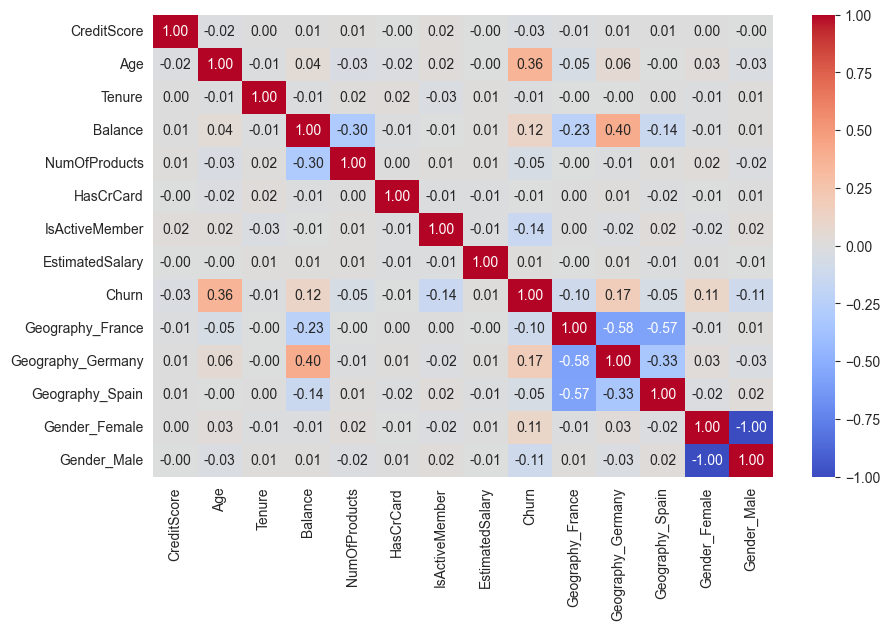

```
================================================================================
CORRELATION OF FEATURES WITH TARGET VARIABLE 'Churn'
Churn                1.000000
Age                  0.358888
Geography_Germany    0.172718
Balance              0.116932
Gender_Female        0.106843
EstimatedSalary      0.011120
HasCrCard           -0.007369
Tenure              -0.013832
CreditScore         -0.025456
NumOfProducts       -0.050396
Geography_Spain     -0.053516
Geography_France    -0.103705
Gender_Male         -0.106843
IsActiveMember      -0.144331
Name: Churn, dtype: float64
```

```python
# Visualise correlation between features and target
corr = df_encoded.corr()
sns.heatmap(corr, annot=True, fmt='.2f', cmap='coolwarm')
plt.show()

# Determine correlation of features with target
corr_target = corr['Churn'].sort_values(ascending=False)
print("\n" + "="*80)
print("CORRELATION OF FEATURES WITH TARGET VARIABLE 'Churn'")
print(corr_target)
```

## Determine Model Performance on Baseline Data

In this section, I will first determine how the models perform on the baseline data, i.e. dataset whose features have not been engineered yet. We can then compare this performance down the line with engineered features and tuned models.

### Split and Scale Data

```python
# Split into features and target variable
X = df_encoded.drop('Churn', axis=1)
y = df_encoded['Churn']
```

```python
# Split into training and testing sets
X_train, X_test, y_train, y_test = train_test_split(X, y, test_size=0.2, random_state=42)
print("Training and testing sets created successfully!")
```

```
Training and testing sets created successfully!
```

```python
# Store training columns in dataframe for later use
train_columns = X_train.columns
```

### Scaling

```python
# scale features, ready for modelling
scaler = StandardScaler()
X_train = scaler.fit_transform(X_train)
X_test = scaler.transform(X_test)
```

### Build Models

```python
# For regression problems, use Lasso Regression to handle overfitting
'''
lasso = LassoCV(cv=5, random_state=0) # Pick best alpha via cross-validation
lasso.fit(X_train, y_train) # Train model

print("Best alpha selected by LassoCV:", lasso.alpha_)
print("\nCoefficients of features: ", lasso.coef_)
'''
```

```python
# Get list of selected features
'''
coef = lasso.coef_
sel_features = train_columns[coef != 0]
print("Selected features: ", sel_features)
'''
```

```python
# Define Helper Function for Model Evaluation
def evaluate_model(model, X_train, y_train, X_test, y_test, use_smote=False):
    """
    Trains and evaluates a classification model.
    Optionally applies SMOTE for resampling imbalanced data.

    Parameters:
        model: scikit-learn model object
        X_train, y_train, X_test, y_test: training and testing sets
        use_smote: bool, whether to apply SMOTE (for KNN in this example)

    Returns:
        dict: containing model name and performance metrics
    """
    if use_smote:
        smote = SMOTE(random_state=42)
        X_train, y_train = smote.fit_resample(X_train, y_train)

    model.fit(X_train, y_train)
    y_pred = model.predict(X_test)
    y_pred_proba = model.predict_proba(X_test)[:, 1] if hasattr(model, "predict_proba") else np.zeros_like(y_pred)

    return {
        'Accuracy': accuracy_score(y_test, y_pred),
        'Recall': recall_score(y_test, y_pred),
        'Precision': precision_score(y_test, y_pred),
        'F1-Score': f1_score(y_test, y_pred),
        'AUC-ROC': roc_auc_score(y_test, y_pred_proba),
        'Confusion Metrix': confusion_matrix(y_test, y_pred)
    }
```

```python
# Define Models to Compare
models = {
    'Logistic Regression': LogisticRegression(class_weight='balanced',
                        penalty='l1', # Using L1 penalty for feature selection to reduce overfitting
                        solver='liblinear',
                        max_iter=1000,
                        random_state=42),
    # 'Lasso Regression': Lasso(alpha=0.00065,  # Select alpha based on previous LassoCV results
    #                          random_state=42), # This is a feature-selection technique that helps to reduce overfitting by removing less important features
    'Decision Tree': DecisionTreeClassifier(class_weight='balanced',
                        max_depth=5,
                        min_samples_split=50,
                        min_samples_leaf=20,
                        random_state=42),
    'Random Forest': RandomForestClassifier(class_weight='balanced',
                        n_estimators=100,
                        max_depth=10,
                        min_samples_split=50,
                        min_samples_leaf=20,
                        random_state=42),
    'Gradient Boosting': GradientBoostingClassifier(n_estimators=100,
                        learning_rate=0.1,
                        max_depth=5,
                        min_samples_split=50,
                        min_samples_leaf=20,
                        random_state=42),
    'KNN (SMOTE)': KNeighborsClassifier(n_neighbors=5),
    'SVC' : SVC(class_weight='balanced',
                        probability=True)
}
```

```python
# Train and Evaluate All Models
results = []
for name, model in models.items():
    print(f"\nTraining {name}...")
    use_smote = True if 'KNN' in name else False
    metrics = evaluate_model(model, X_train, y_train, X_test, y_test, use_smote)
    metrics['Model'] = name
    results.append(metrics)

print("\nAll models have been trained succesfully!")

# Convert results to DataFrame
results_df = pd.DataFrame(results)
```

```
Training Logistic Regression...

Training Decision Tree...

Training Random Forest...

Training Gradient Boosting...

Training KNN (SMOTE)...

Training SVC...

All models have been trained succesfully!
```

```python
# Display Model Comparison Summary
print("\n" + "=" * 80)
print("COMPARISON SUMMARY 'UNTUNED' MODELS AND UNENGINEERED FEATURES")
print("=" * 80)
print(results_df.to_string(index=False))
```

```
================================================================================
COMPARISON SUMMARY 'UNTUNED' MODELS AND UNENGINEERED FEATURES
================================================================================
 Accuracy   Recall  Precision  F1-Score  AUC-ROC          Confusion Metrix               Model
 0.740280 0.751232   0.432624  0.549055 0.809764 [[1123, 400], [101, 305]] Logistic Regression
 0.749093 0.800493   0.446429  0.573192 0.847476  [[1120, 403], [81, 325]]       Decision Tree
 0.808709 0.733990   0.533095  0.617617 0.860887 [[1262, 261], [108, 298]]       Random Forest
 0.856402 0.497537   0.734545  0.593245 0.862580  [[1450, 73], [204, 202]]   Gradient Boosting
 0.746501 0.652709   0.432300  0.520118 0.762604 [[1175, 348], [141, 265]]         KNN (SMOTE)
 0.796267 0.736453   0.511111  0.603431 0.847471 [[1237, 286], [107, 299]]                 SVC
```

`NOTE`

Model with the best Precision: Gradient Boosting (Precision: 0.73, accuracy: 0.86) Model with the best Recall: Decision Tree (Recall: 0.80)

The choice of model will depend on the company's objective. If they are more concerned about higher positive predictions (high precision model) or to catch more likelihood of churn (higher recall)

## Hyperparameter Tuning with GridSearchCV

### Tuning Logistic Regression Model

```python
# Hyperparameter Tuning for Logistic Regression Model
lr_param_grid_1 = {
    'C': [0.001, 0.01, 0.1, 1, 10, 100, 1000],
    'penalty': ['l1', 'l2'],
    'solver': ['liblinear', 'saga'],
    'max_iter': [1000, 2000],
    'class_weight': ['balanced', None]
}

lr_grid_1 = GridSearchCV(LogisticRegression(random_state=42),
                       param_grid=lr_param_grid_1,
                       cv=5,
                       scoring='recall',
                       verbose=2,
                       n_jobs=-1)

lr_grid_1.fit(X_train, y_train)
```

```
Fitting 5 folds for each of 112 candidates, totalling 560 fits
```

```
GridSearchCV(cv=5, estimator=LogisticRegression(random_state=42), n_jobs=-1,
             param_grid={'C': [0.001, 0.01, 0.1, 1, 10, 100, 1000],
                         'class_weight': ['balanced', None],
                         'max_iter': [1000, 2000], 'penalty': ['l1', 'l2'],
                         'solver': ['liblinear', 'saga']},
             scoring='recall', verbose=2)
```

```python
# Print best parameters from GridSearchCV
print("Best Parameters from GridSearchCV for Logistic Regression:")
print(lr_grid_1.best_params_)
print("\nBest Estimator from GridSearchCV for Logistic Regression:")
print(lr_grid_1.best_estimator_)
print("\nBest Score:", lr_grid_1.best_score_)
```

```
Best Parameters from GridSearchCV for Logistic Regression:
{'C': 0.001, 'class_weight': 'balanced', 'max_iter': 1000, 'penalty': 'l1', 'solver': 'liblinear'}

Best Estimator from GridSearchCV for Logistic Regression:
LogisticRegression(C=0.001, class_weight='balanced', max_iter=1000,
                   penalty='l1', random_state=42, solver='liblinear')

Best Score: 0.7586507543903042
```

```python
# Make predictions with the best estimator
best_lr_model = lr_grid_1.best_estimator_
lr_grid_pred = best_lr_model.predict(X_test)
```

```python
# Evaluate tuned Logistic Regression model
print(classification_report(y_test, lr_grid_pred))
```

```
              precision    recall  f1-score   support

           0       0.92      0.62      0.74      1523
           1       0.35      0.79      0.49       406

    accuracy                           0.65      1929
   macro avg       0.63      0.70      0.61      1929
weighted avg       0.80      0.65      0.68      1929
```

### Tuning SVC Model

```python
# Hyperparameter Tuning for SVC Model
param_grid_svc_1 = {'C': [0.1, 1, 10, 100, 1000],
			'gamma': [1, 0.1, 0.01, 0.001, 0.0001],
			'kernel': ['rbf']}

svc_grid_1 = GridSearchCV(SVC(),
                          param_grid_svc_1,
                          refit = True,
                          verbose = 3,
                          scoring='recall')

svc_grid_1.fit(X_train, y_train)
```

```
Fitting 5 folds for each of 25 candidates, totalling 125 fits
[CV 1/5] END ........C=0.1, gamma=1, kernel=rbf;, score=0.000 total time=   3.6s
[CV 2/5] END ........C=0.1, gamma=1, kernel=rbf;, score=0.000 total time=   2.4s
[CV 3/5] END ........C=0.1, gamma=1, kernel=rbf;, score=0.000 total time=   2.2s
[CV 4/5] END ........C=0.1, gamma=1, kernel=rbf;, score=0.000 total time=   2.1s
[CV 5/5] END ........C=0.1, gamma=1, kernel=rbf;, score=0.000 total time=   1.8s
[CV 1/5] END ......C=0.1, gamma=0.1, kernel=rbf;, score=0.122 total time=   0.8s
[CV 2/5] END ......C=0.1, gamma=0.1, kernel=rbf;, score=0.135 total time=   0.9s
[CV 3/5] END ......C=0.1, gamma=0.1, kernel=rbf;, score=0.145 total time=   0.9s
[CV 4/5] END ......C=0.1, gamma=0.1, kernel=rbf;, score=0.132 total time=   1.2s
[CV 5/5] END ......C=0.1, gamma=0.1, kernel=rbf;, score=0.141 total time=   0.9s
[CV 1/5] END .....C=0.1, gamma=0.01, kernel=rbf;, score=0.000 total time=   0.9s
[CV 2/5] END .....C=0.1, gamma=0.01, kernel=rbf;, score=0.000 total time=   0.9s
[CV 3/5] END .....C=0.1, gamma=0.01, kernel=rbf;, score=0.000 total time=   0.9s
[CV 4/5] END .....C=0.1, gamma=0.01, kernel=rbf;, score=0.000 total time=   0.8s
[CV 5/5] END .....C=0.1, gamma=0.01, kernel=rbf;, score=0.000 total time=   0.9s
[CV 1/5] END ....C=0.1, gamma=0.001, kernel=rbf;, score=0.000 total time=   0.8s
[CV 2/5] END ....C=0.1, gamma=0.001, kernel=rbf;, score=0.000 total time=   0.8s
[CV 3/5] END ....C=0.1, gamma=0.001, kernel=rbf;, score=0.000 total time=   0.9s
[CV 4/5] END ....C=0.1, gamma=0.001, kernel=rbf;, score=0.000 total time=   0.9s
[CV 5/5] END ....C=0.1, gamma=0.001, kernel=rbf;, score=0.000 total time=   0.9s
[CV 1/5] END ...C=0.1, gamma=0.0001, kernel=rbf;, score=0.000 total time=   0.9s
[CV 2/5] END ...C=0.1, gamma=0.0001, kernel=rbf;, score=0.000 total time=   0.9s
[CV 3/5] END ...C=0.1, gamma=0.0001, kernel=rbf;, score=0.000 total time=   0.8s
[CV 4/5] END ...C=0.1, gamma=0.0001, kernel=rbf;, score=0.000 total time=   0.8s
[CV 5/5] END ...C=0.1, gamma=0.0001, kernel=rbf;, score=0.000 total time=   0.8s
[CV 1/5] END ..........C=1, gamma=1, kernel=rbf;, score=0.090 total time=   2.6s
[CV 2/5] END ..........C=1, gamma=1, kernel=rbf;, score=0.106 total time=   2.3s
[CV 3/5] END ..........C=1, gamma=1, kernel=rbf;, score=0.100 total time=   2.3s
[CV 4/5] END ..........C=1, gamma=1, kernel=rbf;, score=0.135 total time=   2.0s
[CV 5/5] END ..........C=1, gamma=1, kernel=rbf;, score=0.135 total time=   2.5s
[CV 1/5] END ........C=1, gamma=0.1, kernel=rbf;, score=0.407 total time=   0.8s
[CV 2/5] END ........C=1, gamma=0.1, kernel=rbf;, score=0.394 total time=   0.8s
[CV 3/5] END ........C=1, gamma=0.1, kernel=rbf;, score=0.395 total time=   0.8s
[CV 4/5] END ........C=1, gamma=0.1, kernel=rbf;, score=0.428 total time=   1.0s
[CV 5/5] END ........C=1, gamma=0.1, kernel=rbf;, score=0.372 total time=   1.0s
[CV 1/5] END .......C=1, gamma=0.01, kernel=rbf;, score=0.215 total time=   1.2s
[CV 2/5] END .......C=1, gamma=0.01, kernel=rbf;, score=0.224 total time=   0.8s
[CV 3/5] END .......C=1, gamma=0.01, kernel=rbf;, score=0.193 total time=   0.8s
[CV 4/5] END .......C=1, gamma=0.01, kernel=rbf;, score=0.222 total time=   0.9s
```

[output cut: 71 more lines]

```
[CV 1/5] END ....C=1000, gamma=0.01, kernel=rbf;, score=0.439 total time=   7.3s
[CV 2/5] END ....C=1000, gamma=0.01, kernel=rbf;, score=0.420 total time=   6.4s
[CV 3/5] END ....C=1000, gamma=0.01, kernel=rbf;, score=0.453 total time=   5.3s
[CV 4/5] END ....C=1000, gamma=0.01, kernel=rbf;, score=0.457 total time=   5.6s
[CV 5/5] END ....C=1000, gamma=0.01, kernel=rbf;, score=0.423 total time=   5.4s
[CV 1/5] END ...C=1000, gamma=0.001, kernel=rbf;, score=0.378 total time=   1.5s
[CV 2/5] END ...C=1000, gamma=0.001, kernel=rbf;, score=0.356 total time=   1.5s
[CV 3/5] END ...C=1000, gamma=0.001, kernel=rbf;, score=0.354 total time=   1.6s
[CV 4/5] END ...C=1000, gamma=0.001, kernel=rbf;, score=0.402 total time=   1.4s
[CV 5/5] END ...C=1000, gamma=0.001, kernel=rbf;, score=0.362 total time=   1.6s
[CV 1/5] END ..C=1000, gamma=0.0001, kernel=rbf;, score=0.006 total time=   1.0s
[CV 2/5] END ..C=1000, gamma=0.0001, kernel=rbf;, score=0.013 total time=   1.1s
[CV 3/5] END ..C=1000, gamma=0.0001, kernel=rbf;, score=0.010 total time=   1.2s
[CV 4/5] END ..C=1000, gamma=0.0001, kernel=rbf;, score=0.006 total time=   1.3s
[CV 5/5] END ..C=1000, gamma=0.0001, kernel=rbf;, score=0.003 total time=   1.1s
```

```
GridSearchCV(estimator=SVC(),
             param_grid={'C': [0.1, 1, 10, 100, 1000],
                         'gamma': [1, 0.1, 0.01, 0.001, 0.0001],
                         'kernel': ['rbf']},
             scoring='recall', verbose=3)
```

```python
# Print best parameters from GridSearchCV
print("Best Parameters from GridSearchCV for SVC:")
print(svc_grid_1.best_params_)
print("\nBest Estimators from GridSearchCV for SVC:")
print(svc_grid_1.best_estimator_)
```

```
Best Parameters from GridSearchCV for SVC:
{'C': 1000, 'gamma': 0.1, 'kernel': 'rbf'}

Best Estimators from GridSearchCV for SVC:
SVC(C=1000, gamma=0.1)
```

```python
# Make predictions with the best estimator
svc_best_model = svc_grid_1.best_estimator_
svc_grid_1_pred = svc_best_model.predict(X_test)
```

```python
# Evaluate tuned svc model
print(classification_report(y_test, svc_grid_1_pred))
```

```
              precision    recall  f1-score   support

           0       0.86      0.85      0.86      1523
           1       0.47      0.49      0.48       406

    accuracy                           0.78      1929
   macro avg       0.67      0.67      0.67      1929
weighted avg       0.78      0.78      0.78      1929
```

### Tuning RandomForest Model

```python
# Tuning RandomForest Model
rf_param_grid_1 = {
    'n_estimators': [100, 200],
    'max_depth': [None, 10, 20],
    'min_samples_split': [2, 5],
    'min_samples_leaf': [1, 2],
    'bootstrap': [True, False],
    'class_weight': ['balanced'],
}

rf_grid_1 = GridSearchCV(RandomForestClassifier(),
                         param_grid=rf_param_grid_1,
                         cv=5,
                         scoring='recall')
rf_grid_1.fit(X_train, y_train)
```

```
GridSearchCV(cv=5, estimator=RandomForestClassifier(),
             param_grid={'bootstrap': [True, False],
                         'class_weight': ['balanced'],
                         'max_depth': [None, 10, 20],
                         'min_samples_leaf': [1, 2],
                         'min_samples_split': [2, 5],
                         'n_estimators': [100, 200]},
             scoring='recall')
```

```python
# Print best parameters from GridSearchCV for RandomForest
print("Best Parameters:", rf_grid_1.best_params_)
print("\nBest Estimator:", rf_grid_1.best_estimator_)
```

```
Best Parameters: {'bootstrap': False, 'class_weight': 'balanced', 'max_depth': 10, 'min_samples_leaf': 2, 'min_samples_split': 5, 'n_estimators': 200}

Best Estimator: RandomForestClassifier(bootstrap=False, class_weight='balanced', max_depth=10,
                       min_samples_leaf=2, min_samples_split=5,
                       n_estimators=200)
```

```python
# Make predictions with the best estimator
best_rf_model = rf_grid_1.best_estimator_
rf_grid_1_pred = best_rf_model.predict(X_test)
```

```python
# Evaluate tuned RandomForest model
print(classification_report(y_test, rf_grid_1_pred))
```

```
              precision    recall  f1-score   support

           0       0.91      0.86      0.88      1523
           1       0.56      0.67      0.61       406

    accuracy                           0.82      1929
   macro avg       0.73      0.76      0.75      1929
weighted avg       0.83      0.82      0.82      1929
```

### Tuning Decision Tree Model

```python
# Set up the parameter grid for GridSearchCV
dt_param_grid_1 = {
    'criterion': ['gini', 'entropy'],
    'max_depth': [None, 10, 20, 30, 40, 50],
    'min_samples_split': [2, 5, 10],
    'min_samples_leaf': [1, 2, 4],
    'max_features': ['auto', 'sqrt', 'log2'],
    'class_weight': ['balanced', {0: 1, 1: 2}, {0: 1, 1: 3}]
}

# Initialize the Decision Tree model
dt_model = DecisionTreeClassifier(random_state=42)
```

```python
# Set up GridSearchCV
dt_grid_1 = GridSearchCV(estimator=dt_model, param_grid=dt_param_grid_1,
                           scoring='recall',
                           cv=5,
                           verbose=2,
                           n_jobs=-1)

# Fit GridSearchCV
dt_grid_1.fit(X_train, y_train)
```

```
Fitting 5 folds for each of 972 candidates, totalling 4860 fits
```

```
GridSearchCV(cv=5, estimator=DecisionTreeClassifier(random_state=42), n_jobs=-1,
             param_grid={'class_weight': ['balanced', {0: 1, 1: 2},
                                          {0: 1, 1: 3}],
                         'criterion': ['gini', 'entropy'],
                         'max_depth': [None, 10, 20, 30, 40, 50],
                         'max_features': ['auto', 'sqrt', 'log2'],
                         'min_samples_leaf': [1, 2, 4],
                         'min_samples_split': [2, 5, 10]},
             scoring='recall', verbose=2)
```

```python
# Print the best parameters and best score
print("Best Parameters:", dt_grid_1.best_params_)
print("\nBest Estimator:", dt_grid_1.best_estimator_)
print("\nBest Score:", dt_grid_1.best_score_)
```

```
Best Parameters: {'class_weight': 'balanced', 'criterion': 'entropy', 'max_depth': 10, 'max_features': 'sqrt', 'min_samples_leaf': 4, 'min_samples_split': 10}

Best Estimator: DecisionTreeClassifier(class_weight='balanced', criterion='entropy',
                       max_depth=10, max_features='sqrt', min_samples_leaf=4,
                       min_samples_split=10, random_state=42)

Best Score: 0.6874185835600626
```

```python
# Make predictions with the best estimator
best_dt_model = dt_grid_1.best_estimator_
dt_grid_1_pred = best_dt_model.predict(X_test)
```

```python
# Evaluate the model
print(classification_report(y_test, dt_grid_1_pred))
print(confusion_matrix(y_test, dt_grid_1_pred))
```

```
              precision    recall  f1-score   support

           0       0.91      0.76      0.82      1523
           1       0.44      0.70      0.54       406

    accuracy                           0.75      1929
   macro avg       0.67      0.73      0.68      1929
weighted avg       0.81      0.75      0.76      1929

[[1152  371]
 [ 120  286]]
```

## Feature Engineering

Now, I will implement some feature engineering to see how it affects the models

```python
# Create a copy for engineered features
df_engineered = df_encoded.copy()
```

```python
df_engineered.head()
```

|  | CreditScore | Age | Tenure | Balance | NumOfProducts | HasCrCard | IsActiveMember | EstimatedSalary | Churn | Geography_France | Geography_Germany | Geography_Spain | Gender_Female | Gender_Male |
| --- | --- | --- | --- | --- | --- | --- | --- | --- | --- | --- | --- | --- | --- | --- |
| 0 | 619 | 42 | 2 | 0.00 | 1 | 1 | 1 | 101348.88 | 1 | True | False | False | True | False |
| 1 | 608 | 41 | 1 | 83807.86 | 1 | 0 | 1 | 112542.58 | 0 | False | False | True | True | False |
| 2 | 502 | 42 | 8 | 159660.80 | 3 | 1 | 0 | 113931.57 | 1 | True | False | False | True | False |
| 3 | 699 | 39 | 1 | 0.00 | 2 | 0 | 0 | 93826.63 | 0 | True | False | False | True | False |
| 4 | 850 | 43 | 2 | 125510.82 | 1 | 1 | 1 | 79084.10 | 0 | False | False | True | True | False |

```python
# Feature Engineering
df_engineered['Bal_Sal_Ratio'] = df_engineered['Balance'] / (df_engineered['EstimatedSalary'] + 1)
df_engineered['ProductsPerYear'] = df_engineered['NumOfProducts'] / (df_engineered['Tenure'] + 1)
df_engineered['ActiveCreditInteraction'] = df_engineered['HasCrCard'] * df_engineered['IsActiveMember']
```

```python
# Age and credit score bins
df_engineered['Age_Bin'] = pd.cut(df_engineered['Age'], bins=[0, 25, 45, 65, 120], labels=['Young', 'Adult', 'MidAge', 'Senior'])
df_engineered['CreditScore_Bin'] = pd.cut(df_engineered['CreditScore'],
                              bins=[0, 580, 670, 740, 800, 900],
                              labels=['Poor', 'Fair', 'Good', 'VeryGood', 'Excellent'])
```

### Exploratory Data Analysis on Engineered Features

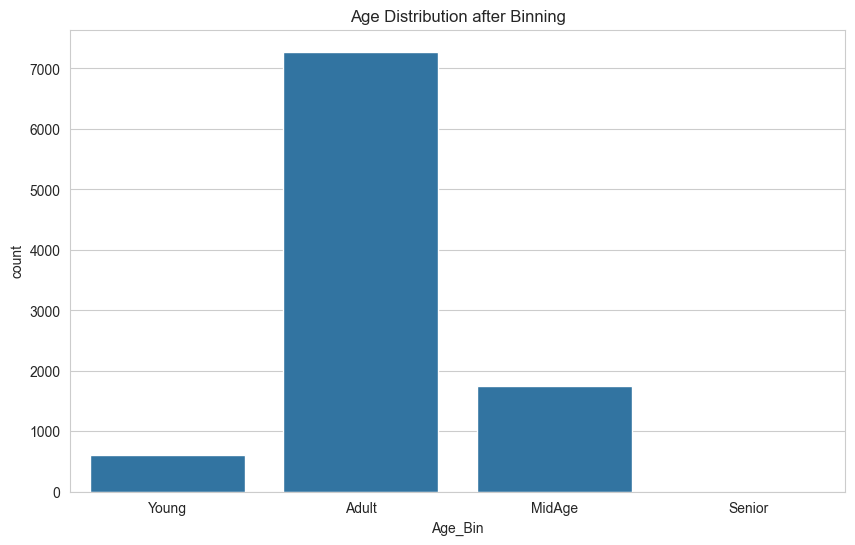

```python
# Visualise the Age distribution after binning
sns.countplot(data=df_engineered, x='Age_Bin', order=['Young', 'Adult', 'MidAge', 'Senior'])
plt.title('Age Distribution after Binning')
plt.show()
```

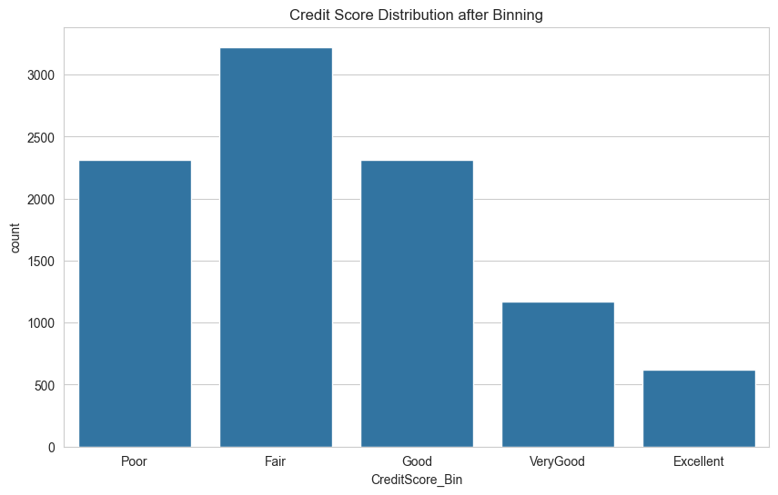

```python
# Visualise the Credit Score distribution after binning
sns.countplot(data=df_engineered, x='CreditScore_Bin', order=['Poor', 'Fair', 'Good', 'VeryGood', 'Excellent'])
plt.title('Credit Score Distribution after Binning')
plt.show()
```

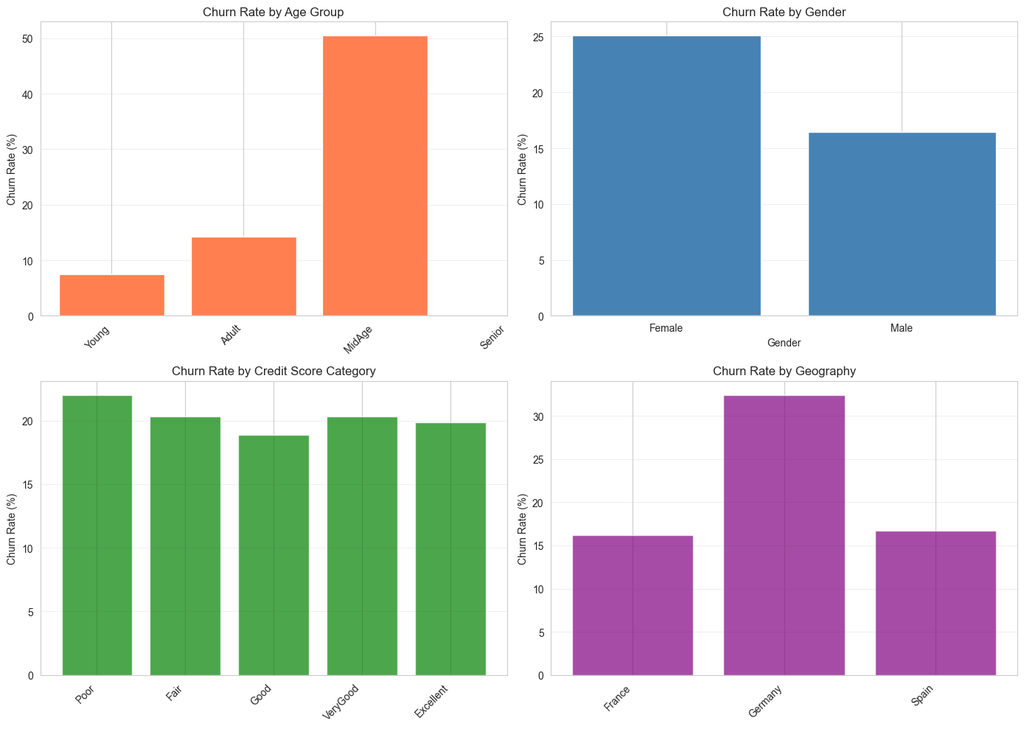

```python
# Visualization: Churn rate by key categories
fig, axes = plt.subplots(2, 2, figsize=(14, 10))

# Age group
churn_by_age_plot = df_engineered.groupby('Age_Bin')['Churn'].mean() * 100
axes[0, 0].bar(range(len(churn_by_age_plot)), churn_by_age_plot.values, color='coral')
axes[0, 0].set_xticks(range(len(churn_by_age_plot)))
axes[0, 0].set_xticklabels(churn_by_age_plot.index, rotation=45, ha='right')
axes[0, 0].set_ylabel('Churn Rate (%)')
axes[0, 0].set_title('Churn Rate by Age Group')
axes[0, 0].grid(axis='y', alpha=0.3)

# By Gender
churn_by_gender_plot = df.groupby('Gender')['Churn'].mean() * 100
axes[0, 1].bar(churn_by_gender_plot.index, churn_by_gender_plot.values, color='steelblue')
axes[0, 1].set_xlabel('Gender')
axes[0, 1].set_ylabel('Churn Rate (%)')
axes[0, 1].set_title('Churn Rate by Gender')
axes[0, 1].grid(axis='y', alpha=0.3)

# Credit Score category
churn_by_cs_plot = df_engineered.groupby('CreditScore_Bin')['Churn'].mean() * 100
axes[1, 0].bar(range(len(churn_by_cs_plot)), churn_by_cs_plot.values, color='green', alpha=0.7)
axes[1, 0].set_xticks(range(len(churn_by_cs_plot)))
axes[1, 0].set_xticklabels(churn_by_cs_plot.index, rotation=45, ha='right')
axes[1, 0].set_ylabel('Churn Rate (%)')
axes[1, 0].set_title('Churn Rate by Credit Score Category')
axes[1, 0].grid(axis='y', alpha=0.3)

# Geography category
churn_by_geography_plot = df.groupby('Geography')['Churn'].mean() * 100
axes[1, 1].bar(range(len(churn_by_geography_plot)), churn_by_geography_plot.values, color='purple', alpha=0.7)
axes[1, 1].set_xticks(range(len(churn_by_geography_plot)))
axes[1, 1].set_xticklabels(churn_by_geography_plot.index, rotation=45, ha='right')
axes[1, 1].set_ylabel('Churn Rate (%)')
axes[1, 1].set_title('Churn Rate by Geography')
axes[1, 1].grid(axis='y', alpha=0.3)

plt.tight_layout()
plt.show()
```

```
Top features correlated with Churn:
Age                  0.358888
Geography_Germany    0.172718
Balance              0.116932
Gender_Female        0.106843
Bal_Sal_Ratio        0.026309
EstimatedSalary      0.011120
ProductsPerYear     -0.005497
HasCrCard           -0.007369
Tenure              -0.013832
CreditScore         -0.025456
Name: Churn, dtype: float64
```

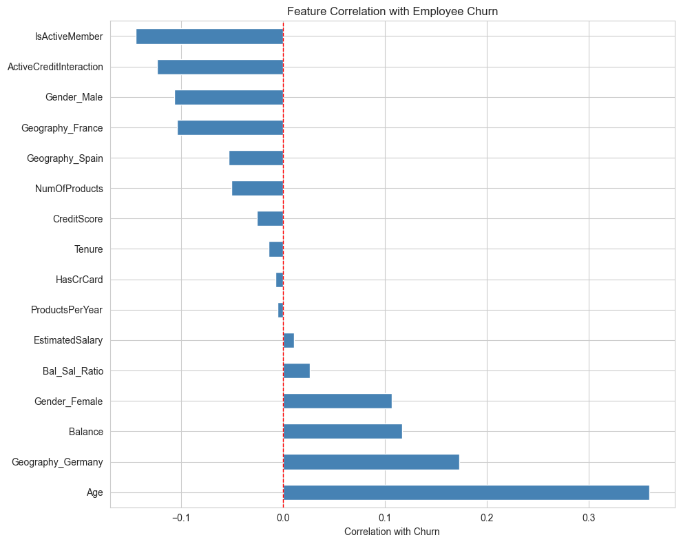

```python
# Analyze feature importance with engineered features
analysis_features = [
    'CreditScore', 'Age', 'Tenure', 'Balance', 'NumOfProducts', 'HasCrCard',
       'IsActiveMember', 'EstimatedSalary', 'Geography_France',
       'Geography_Germany', 'Geography_Spain', 'Gender_Female', 'Gender_Male',
       'Bal_Sal_Ratio', 'ProductsPerYear', 'ActiveCreditInteraction'
]

# Calculate correlation with Churn
correlations = df_engineered[analysis_features + ['Churn']].corr()['Churn'].drop('Churn').sort_values(ascending=False)

print("\nTop features correlated with Churn:")
print(correlations.head(10))

# Visualize feature importance through correlation
plt.figure(figsize=(10, 8))
correlations.plot(kind='barh', color='steelblue')
plt.xlabel('Correlation with Churn')
plt.title('Feature Correlation with Employee Churn')
plt.axvline(x=0, color='red', linestyle='--', linewidth=1)
plt.tight_layout()
plt.show()
```

## Determine Model Performance on Engineered Features

### Split and Scale Data

```python
# Drop categorical columns
df_engineered = df_engineered.drop(['Age_Bin', 'CreditScore_Bin'], axis=1)
```

```python
# Split into features and target variable
X = df_engineered.drop('Churn', axis=1)
y = df_engineered['Churn']

# Split into training and testing sets
X_train, X_test, y_train, y_test = train_test_split(X, y, test_size=0.2, random_state=42)
print("Data split into training and testing sets successfully!")
```

```
Data split into training and testing sets successfully!
```

### Scaling

```python
# scale features, ready for modelling
scaler = StandardScaler()
X_train = scaler.fit_transform(X_train)
X_test = scaler.transform(X_test)
```

### Train and Evaluate All Models

```python
# Train and Evaluate All Models by calling the already built helper function
results_engr = []
for name, model in models.items():
    print(f"\nTraining {name}...")
    use_smote = True if 'KNN' in name else False
    metrics = evaluate_model(model, X_train, y_train, X_test, y_test, use_smote)
    metrics['Model'] = name
    results_engr.append(metrics)

print("\nAll models have been trained succesfully!")
```

```
Training Logistic Regression...

Training Decision Tree...

Training Random Forest...

Training Gradient Boosting...

Training KNN (SMOTE)...

Training SVC...

All models have been trained succesfully!
```

```python
# Convert results to DataFrame
results_engr_df = pd.DataFrame(results_engr)
```

```python
# Display Model Comparison Summary
print("\n" + "=" * 80)
print("COMPARISON SUMMARY 'UNTUNED' MODELS AND 'ENGINEERED' FEATURES")
print("=" * 80)
print(results_engr_df.to_string(index=False))
print("\n" + "=" * 80)
print("COMPARISON SUMMARY 'UNTUNED' MODELS AND 'UNENGINEERED' FEATURES")
print("=" * 80)
print(results_df.to_string(index=False))
```

[output not shown]

`NOTE`

The Comparison above reveals the models performed better with the unengineered features. Often times this observation is due to information loss during aggregations or binning of features. Expressive (tree-based) models learn temporal patterns, nonlinear relationships, or predictive outliers more from raw datasets. In addition, most models (like the XGB boost, Random forest, KNN) are inherent feature engineers.

Therefore, due to the above reasons, I recommend using the raw dataset for further analysis.